# Delta Lake: Batch Processing and Time Travel

This Jupyter notebook showcases ACID transactions and time travel of batch queries against a Delta Lake table.

### References

- [Get Started with PySpark and Jupyter Notebook in 3 Minutes](https://blog.sicara.com/get-started-pyspark-jupyter-guide-tutorial-ae2fe84f594f)
- [New Databricks Delta Features Simplify Data Pipelines](https://databricks.com/blog/2019/02/19/new-databricks-delta-features-simplify-data-pipelines.html)

## Migrating to Delta Lake

To convert your table to a Delta Lake table, the easiest method is to:

- Load your data to create a DataFrame
- Save it using the `df.write.format("delta").mode(...).save(...)` method
- Load it using `spark.read.format("delta").load(...)`

```python
# Set File Paths
tripdelaysFilePath = "departuredelays.csv"

# Obtain departure Delays data
departureDelays = spark.read.options(header='true', inferSchema='true').csv(tripdelaysFilePath)
departureDelays.createOrReplaceTempView("departureDelays")

# Convert delays to IntegerType()
from pyspark.sql.types import IntegerType
from pyspark.sql.functions import col
departureDelays = departureDelays.withColumn("delay", col("delay").cast(IntegerType()))
```

```python
# Save table as Delta
departureDelays.write.format("delta").mode("overwrite").save("departureDelays.delta")
```

```python
# Load Delta table
delays_delta = spark.read.format("delta").load("departureDelays.delta")
```

```python
# Display data (it is the same except now its in Delta format)
delays_delta.limit(10).toPandas()
```

|  | date | delay | distance | origin | destination |
| --- | --- | --- | --- | --- | --- |
| 0 | 1010630 | -10 | 928 | RSW | EWR |
| 1 | 1021029 | 87 | 974 | RSW | ORD |
| 2 | 1021346 | 0 | 928 | RSW | EWR |
| 3 | 1021044 | 18 | 928 | RSW | EWR |
| 4 | 1021730 | 29 | 748 | RSW | IAH |
| 5 | 1020535 | 605 | 974 | RSW | ORD |
| 6 | 1021820 | 71 | 974 | RSW | ORD |
| 7 | 1021743 | 0 | 928 | RSW | EWR |
| 8 | 1022017 | 0 | 928 | RSW | EWR |
| 9 | 1020600 | -2 | 748 | RSW | IAH |

## Batch Insert New Flights

Let's prepare View Seattle to San Francisco Flights (for a particular date)

```python
# Limit flights to SEA to SFO
sea2sfo = delays_delta \
    .where(col("origin") == 'SEA') \
    .where(col("destination") == 'SFO') \
    .where(col("delay") > 180)

# Display data
sea2sfo.limit(10).toPandas()
```

|  | date | delay | distance | origin | destination |
| --- | --- | --- | --- | --- | --- |
| 0 | 1120924 | 268 | 590 | SEA | SFO |
| 1 | 1061214 | 384 | 590 | SEA | SFO |
| 2 | 1281310 | 250 | 590 | SEA | SFO |
| 3 | 2071845 | 203 | 590 | SEA | SFO |
| 4 | 2091855 | 182 | 590 | SEA | SFO |
| 5 | 2261450 | 259 | 590 | SEA | SFO |
| 6 | 2261855 | 224 | 590 | SEA | SFO |
| 7 | 2271450 | 240 | 590 | SEA | SFO |
| 8 | 2280950 | 207 | 590 | SEA | SFO |
| 9 | 2281450 | 331 | 590 | SEA | SFO |

```python
%matplotlib notebook
```

```python
import numpy as np
import pandas as pd
import seaborn as sns
import matplotlib.pyplot as plt
from scipy import stats
```

```python
# Convert to Pandas for plotting purposes
sea2sfo_pdf = sea2sfo.toPandas()

# Extract delay values to plot histogram
delay = sea2sfo_pdf.loc[:, ['delay']].values
```

[figure not shown]

```python
# Plot delay histogram
sns.set(color_codes=True)
plt.figure(figsize=(5, 5))
sns.distplot(delay);
```

### Create `insert_rows` DataFrame for our New Flights

The `insert_rows` DataFrame contains the new flights that we want to batch add to our Delta Lake table. We will add 10 batches of data into our Delta Lake table `departureDelays`.

```python
# Batch Insert flights
i = 1
while i <= 10:
    # Generate new delays
    delay_a = 500 + 20*i
    delay_b = 500 + 30*i

    # Create new flights
    newflights =  [(4011028, delay_a, 590, 'SEA', 'SFO'), (4021028, delay_b, 590, 'SEA', 'SFO')]
    cols = ['date', 'delay', 'distance', 'origin', 'destination']

    # Create `insert_rows` DataFrame
    insert_rows = spark.createDataFrame(newflights, cols)

    # Convert LongType() to IntegerType()
    insert_rows = insert_rows \
        .withColumn("date", col("date").cast(IntegerType())) \
        .withColumn("delay", col("delay").cast(IntegerType())) \
        .withColumn("distance", col("distance").cast(IntegerType()))

    # Display data
    insert_rows.toPandas()

    # Batch write
    insert_rows.write.format("delta").mode("append").save("departureDelays.delta")

    # Loop through
    i += 1
```

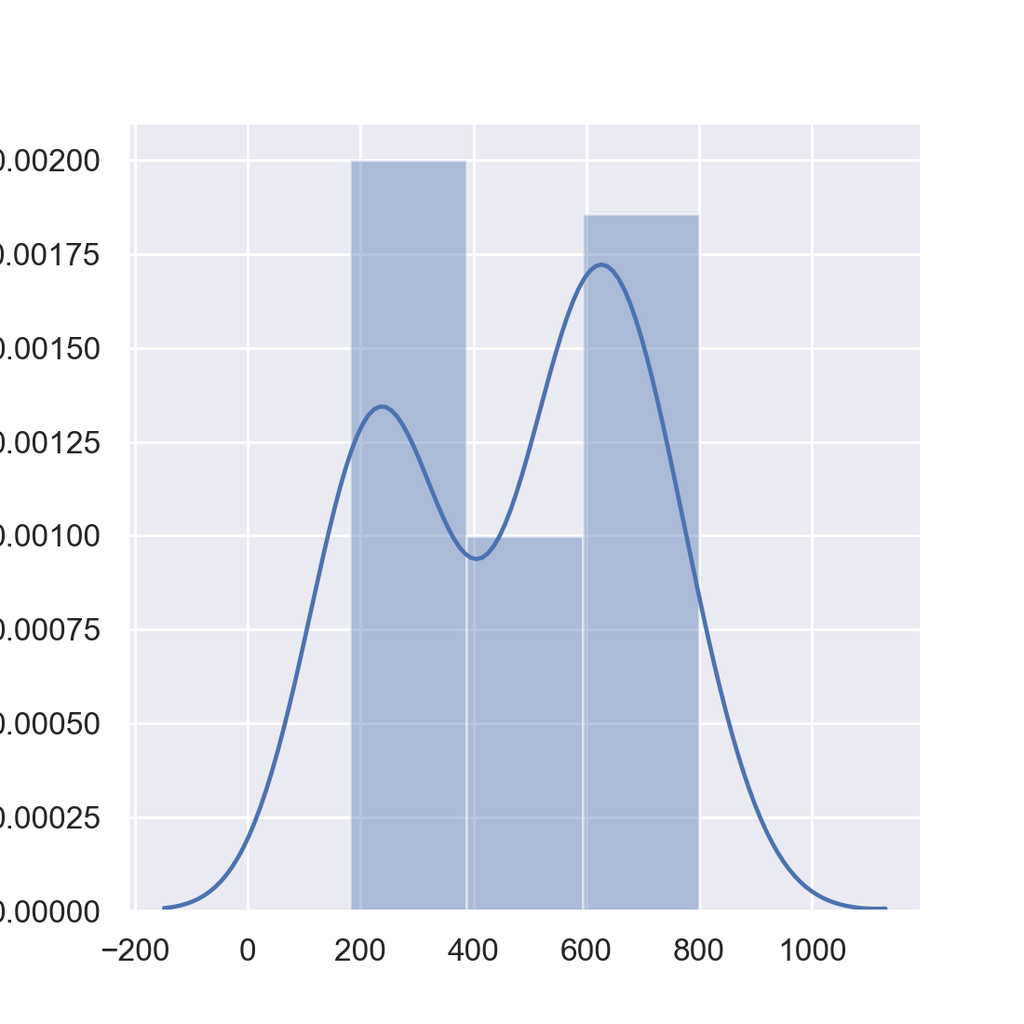

```python
# Reread data
delays_delta = spark.read.format("parquet").load("departureDelays.delta")

# Review data
sea2sfo = delays_delta \
    .where(col("origin") == 'SEA') \
    .where(col("destination") == 'SFO') \
    .where(col("delay") > 180)

# Convert to Pandas for plotting purposes
sea2sfo_pdf = sea2sfo.toPandas()

# Extract delay values to plot histogram
delay = sea2sfo_pdf.loc[:, ['delay']].values

# Plot delay histogram
sns.set(color_codes=True)
plt.figure(figsize=(5, 5))
sns.distplot(delay);
```

## Let's Travel back in Time!

Databricks Delta’s time travel capabilities simplify building data pipelines for the following use cases.

- Audit Data Changes
- Reproduce experiments & reports
- Rollbacks

As you write into a Delta table or directory, every operation is automatically versioned.

You can query by:

1. Using a timestamp
2. Using a version number

using Python, Scala, and/or SQL syntax; for these examples we will use the Python syntax.

For more information, refer to [Introducing Delta Time Travel for Large Scale Data Lakes](https://databricks.com/blog/2019/02/04/introducing-delta-time-travel-for-large-scale-data-lakes.html)

### Obtain Version Number

To see what versions are available, refer to the `_delta_log` folder of your Delta Lake table. It should look similar to below indicating there are 11 versions of your Delta Lake table.

```
/departureDelays.delta/_delta_log$ d
total 248
 8 -rw-r--r--   1 dennylee  staff    128 Apr 20 20:11 .00000000000000000010.checkpoint.parquet.crc
 8 -rw-r--r--   1 dennylee  staff   1489 Apr 20 19:55 00000000000000000000.json
 8 -rw-r--r--   1 dennylee  staff    650 Apr 20 19:58 00000000000000000001.json
 8 -rw-r--r--   1 dennylee  staff    650 Apr 20 20:10 00000000000000000002.json
 8 -rw-r--r--   1 dennylee  staff    650 Apr 20 20:10 00000000000000000003.json
 8 -rw-r--r--   1 dennylee  staff    650 Apr 20 20:10 00000000000000000004.json
 8 -rw-r--r--   1 dennylee  staff    650 Apr 20 20:10 00000000000000000005.json
 8 -rw-r--r--   1 dennylee  staff    650 Apr 20 20:10 00000000000000000006.json
 8 -rw-r--r--   1 dennylee  staff    650 Apr 20 20:10 00000000000000000007.json
 8 -rw-r--r--   1 dennylee  staff    650 Apr 20 20:10 00000000000000000008.json
 8 -rw-r--r--   1 dennylee  staff    650 Apr 20 20:10 00000000000000000009.json
32 -rw-r--r--   1 dennylee  staff  15091 Apr 20 20:11 00000000000000000010.checkpoint.parquet
 8 -rw-r--r--   1 dennylee  staff    650 Apr 20 20:10 00000000000000000010.json
 8 -rw-r--r--   1 dennylee  staff    651 Apr 20 20:11 00000000000000000011.json
 8 -rw-r--r--   1 dennylee  staff     25 Apr 20 20:11 _last_checkpoint
```

```python
!ls ./departureDelays.delta/_delta_log/
```

```
00000000000000000000.json               00000000000000000007.json
00000000000000000001.json               00000000000000000008.json
00000000000000000002.json               00000000000000000009.json
00000000000000000003.json               00000000000000000010.checkpoint.parquet
00000000000000000004.json               00000000000000000010.json
00000000000000000005.json               _last_checkpoint
00000000000000000006.json
```

### Review Delta Lake Versions

The following code shows the 11 different views of the data associated with the different versions of data using the option:

`.option("versionAsOf", version)`

This will initially load the `delays` list so we can plot the numpy arrays directly.

```python
# create empty list
delays = []

# Indicating the first version
version = 0
vmax = 10

while (version <= vmax):
    # Read data
    delays_delta_tt = spark.read.format("delta").option("versionAsOf", version).load("departureDelays.delta")

    # Review data
    sea2sfo = delays_delta_tt \
        .where(col("origin") == 'SEA') \
        .where(col("destination") == 'SFO') \
        .where(col("delay") > 180)

    # Convert to Pandas for plotting purposes
    sea2sfo_pdf = sea2sfo.toPandas()

    # Extract delay values to plot histogram
    delays.append(sea2sfo_pdf.loc[:, ['delay']].values)

    # Looping
    version += 1
```

## Time Travel Subplots

Review and visualize versions 0, 3, 6, and 10 of our `departureDelays` Delta Lake table.

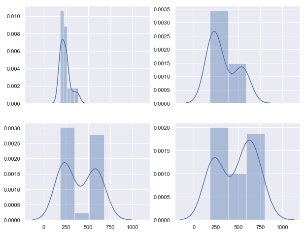

```python
plt.gcf().clear()
sns.set(color_codes=True)
#plt.style.use('seaborn-whitegrid')

f, axes = plt.subplots(2, 2, figsize=(10, 8), sharex=True)
sns.distplot(delays[0], ax=axes[0, 0])
sns.distplot(delays[3], ax=axes[0, 1])
sns.distplot(delays[6], ax=axes[1, 0])
sns.distplot(delays[10], ax=axes[1, 1])
```

## Time Travel Subplots Overlay

Review and visualize all 11 versions of our `departureDelays` Delta Lake table.

```
<module 'seaborn' from '/anaconda3/lib/python3.6/site-packages/seaborn/__init__.py'>
```

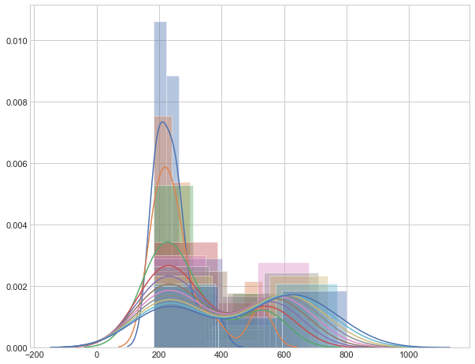

```python
%matplotlib inline
import time
from IPython import display

version = 0 # Indicating the first version
vmax = 10
plt.figure(figsize=(10, 8))
while (version <= vmax):
    # Create plot
    sns.distplot(delays[version]);
    display.clear_output(wait=True)
    display.display(sns)

    # Looping
    version += 1
```